# Polynomial Linear Regression - Udemy MLAZ

Steve Newns

October 5, 2017

Now we are building **non-linear regression models**, where the relationship between the output and inputs is NOT linear.

Business Problem: - We want to predict salaries based on position title and the level - We are in HR and are about to give an offer to a potential nw employee - We must negotiate a salary for the interviewee, who has 25 yrs experience, was a regional manager, and is asking for a minimum of $160k/yr. - We (HR) call their previous employer to verify the info about their previous salary - But, all the info we get from their HR deptartment is a simple table of salaries for 10 positions + levels’

```r
library(tidyverse)
library(ggplot2)
library(caTools)

# import data
salary <- read.csv('Position_Salaries.csv')
summary(salary)
```

```
##               Position     Level           Salary
##  Business Analyst :1   Min.   : 1.00   Min.   :  45000
##  C-level          :1   1st Qu.: 3.25   1st Qu.:  65000
##  CEO              :1   Median : 5.50   Median : 130000
##  Country Manager  :1   Mean   : 5.50   Mean   : 249500
##  Junior Consultant:1   3rd Qu.: 7.75   3rd Qu.: 275000
##  Manager          :1   Max.   :10.00   Max.   :1000000
##  (Other)          :4
```

```r
glimpse(salary)
```

```
## Observations: 10
## Variables: 3
## $ Position <fctr> Business Analyst, Junior Consultant, Senior Consulta...
## $ Level    <int> 1, 2, 3, 4, 5, 6, 7, 8, 9, 10
## $ Salary   <int> 45000, 50000, 60000, 80000, 110000, 150000, 200000, 3...
```

```r
head(salary)
```

```
##            Position Level Salary
## 1  Business Analyst     1  45000
## 2 Junior Consultant     2  50000
## 3 Senior Consultant     3  60000
## 4           Manager     4  80000
## 5   Country Manager     5 110000
## 6    Region Manager     6 150000
```

Let’s just check the distribution just for kicks.

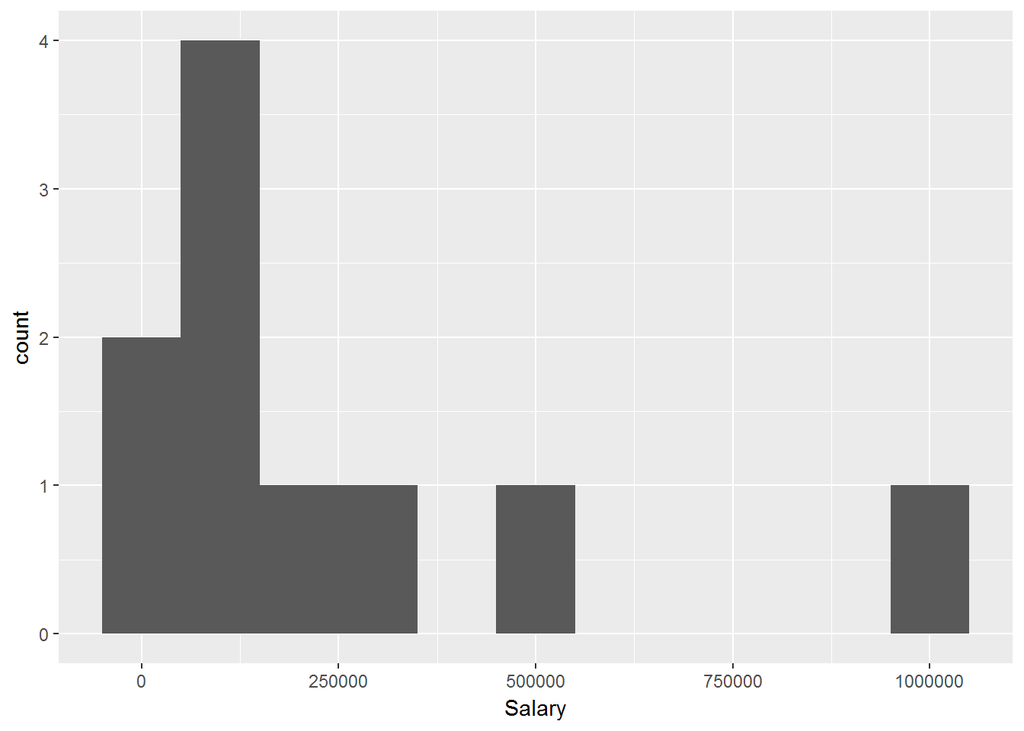

```r
ggplot(salary) +
  geom_histogram(aes(Salary), binwidth = 100000)
```

So it’s pretty right skewed, showing most salaries are below the $250k/year.

Let’s look at the relationship between Level and Salary.

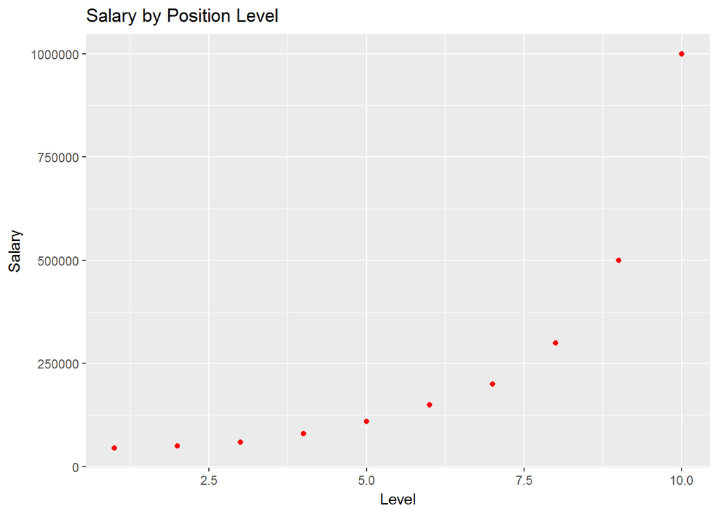

```r
ggplot(salary) +
  geom_point(aes(Level, Salary), colour = 'red') + # plot points
  ggtitle('Salary by Position Level')
```

After plotting, we can see a non-linear relationship between salary and position level

However we know the prospective employee was a regional manager, and it usually takes ~4 years to get from regional manager to partner (next the level up)

So, this employer was between Levels 6 and 7, so we will say he was at level 6.5. Therefore, we can use regression to see if he was bluffing about his previous salary.

We also know that position is directly equivalent to Level (i.e. it’s basically already encoded), so only need to use 1 of these variables in our regression.

```r
# remove positions col
new_salaries <- salary[,c('Level','Salary')]
head(new_salaries,10)
```

```
##    Level  Salary
## 1      1   45000
## 2      2   50000
## 3      3   60000
## 4      4   80000
## 5      5  110000
## 6      6  150000
## 7      7  200000
## 8      8  300000
## 9      9  500000
## 10    10 1000000
```

We don’t need to split our data nor do any feature scaling, since it is such a small dataset, so we can jump straight to running a simple regression model.

```r
set.seed(123)

lin_reg <- lm(Salary ~ ., new_salaries)
summary(lin_reg)
```

```
##
## Call:
## lm(formula = Salary ~ ., data = new_salaries)
##
## Residuals:
##     Min      1Q  Median      3Q     Max
## -170818 -129720  -40379   65856  386545
##
## Coefficients:
##             Estimate Std. Error t value Pr(>|t|)
## (Intercept)  -195333     124790  -1.565  0.15615
## Level          80879      20112   4.021  0.00383 **
## ---
## Signif. codes:  0 '***' 0.001 '**' 0.01 '*' 0.05 '.' 0.1 ' ' 1
##
## Residual standard error: 182700 on 8 degrees of freedom
## Multiple R-squared:  0.669,  Adjusted R-squared:  0.6277
## F-statistic: 16.17 on 1 and 8 DF,  p-value: 0.003833
```

So, with Level’s p-value being < .005, we can say that this model indicates that Level is a “good” predictor of salary, but it could be better (it only has 2 significance stars)

Let’s see if we can improve the model by adding **polynomial features**.

These will be additional indepenent variables that will, in some way, compose a new matrix of features which we will apply a multiple linear regression model to in order to make the whole model a polynomial regression model

So, in short, this polynomial regression model is a multiple regression model composed of 1 independent variable + additional polynomial terms of that independent variable.

This makes the model more “flexible” to try to accurately predict the outcome.

```r
# add new 2-nd order polynomial Level
new_salaries$level_sq <- new_salaries$Level^2
head(new_salaries)
```

```
##   Level Salary level_sq
## 1     1  45000        1
## 2     2  50000        4
## 3     3  60000        9
## 4     4  80000       16
## 5     5 110000       25
## 6     6 150000       36
```

Now to make the model.

```r
poly_reg <- lm(Salary ~., new_salaries)
summary(poly_reg)
```

```
##
## Call:
## lm(formula = Salary ~ ., data = new_salaries)
##
## Residuals:
##     Min      1Q  Median      3Q     Max
## -112833  -68852   10682   55186  153364
##
## Coefficients:
##             Estimate Std. Error t value Pr(>|t|)
## (Intercept)   232167     115571   2.009  0.08451 .
## Level        -132871      48268  -2.753  0.02839 *
## level_sq       19432       4276   4.544  0.00265 **
## ---
## Signif. codes:  0 '***' 0.001 '**' 0.01 '*' 0.05 '.' 0.1 ' ' 1
##
## Residual standard error: 98260 on 7 degrees of freedom
## Multiple R-squared:  0.9162, Adjusted R-squared:  0.8923
## F-statistic: 38.27 on 2 and 7 DF,  p-value: 0.0001703
```

So, level is even less significant here, while the 2nd-order Level is a bit more significant than the Level variable in our original model.

But, R2 and Adj R2 have improved

Let’s check this model against our training (AKA our only) data set.

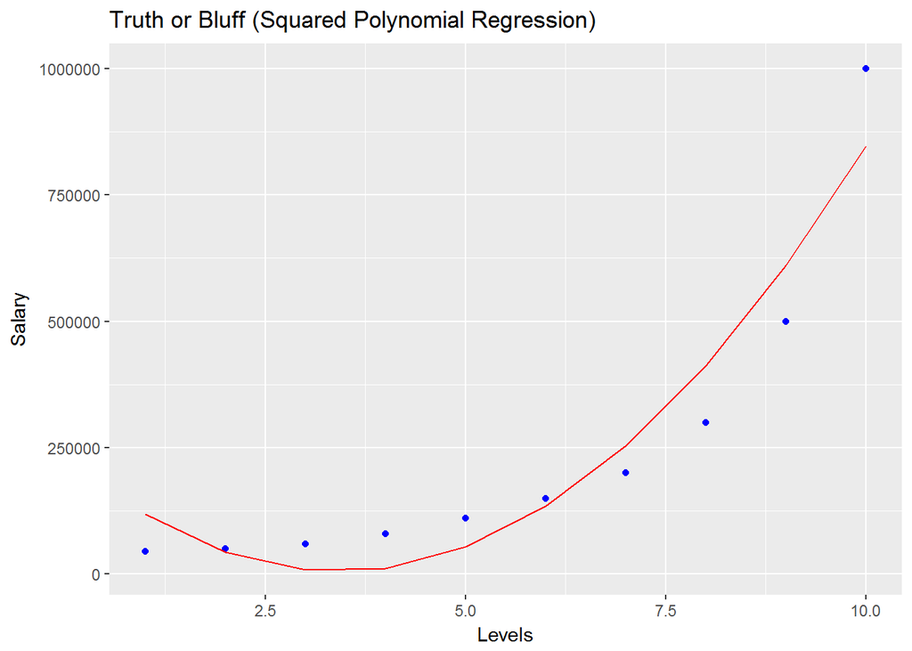

```r
# training predictions
y.pred <- predict(poly_reg, new_salaries)

(squared_plot <- ggplot(new_salaries) +
  geom_point(aes(Level, Salary), colour = 'blue') + # plot points
  geom_line(aes(Level, y.pred), colour = 'red') + # plot regression line
  xlab('Levels') +
  ggtitle('Truth or Bluff (Squared Polynomial Regression)'))
```

Let’s see if a 3rd-order polynomial is even better.

```r
new_salaries$level_cub <- new_salaries$Level^3

poly_reg_3 <- lm(Salary ~., new_salaries)
summary(poly_reg_3)
```

```
##
## Call:
## lm(formula = Salary ~ ., data = new_salaries)
##
## Residuals:
##    Min     1Q Median     3Q    Max
## -75695 -28148   7091  29256  49538
##
## Coefficients:
##              Estimate Std. Error t value Pr(>|t|)
## (Intercept) -121333.3    97544.8  -1.244  0.25994
## Level        180664.3    73114.5   2.471  0.04839 *
## level_sq     -48549.0    15081.0  -3.219  0.01816 *
## level_cub      4120.0      904.3   4.556  0.00387 **
## ---
## Signif. codes:  0 '***' 0.001 '**' 0.01 '*' 0.05 '.' 0.1 ' ' 1
##
## Residual standard error: 50260 on 6 degrees of freedom
## Multiple R-squared:  0.9812, Adjusted R-squared:  0.9718
## F-statistic: 104.4 on 3 and 6 DF,  p-value: 1.441e-05
```

Again, our previous, lower-order Level variables have decreased in significant, but our new 3rd-order variable is significant. Also, again our R2 and Adj R2 have improved.

Now for the predictions and plot.

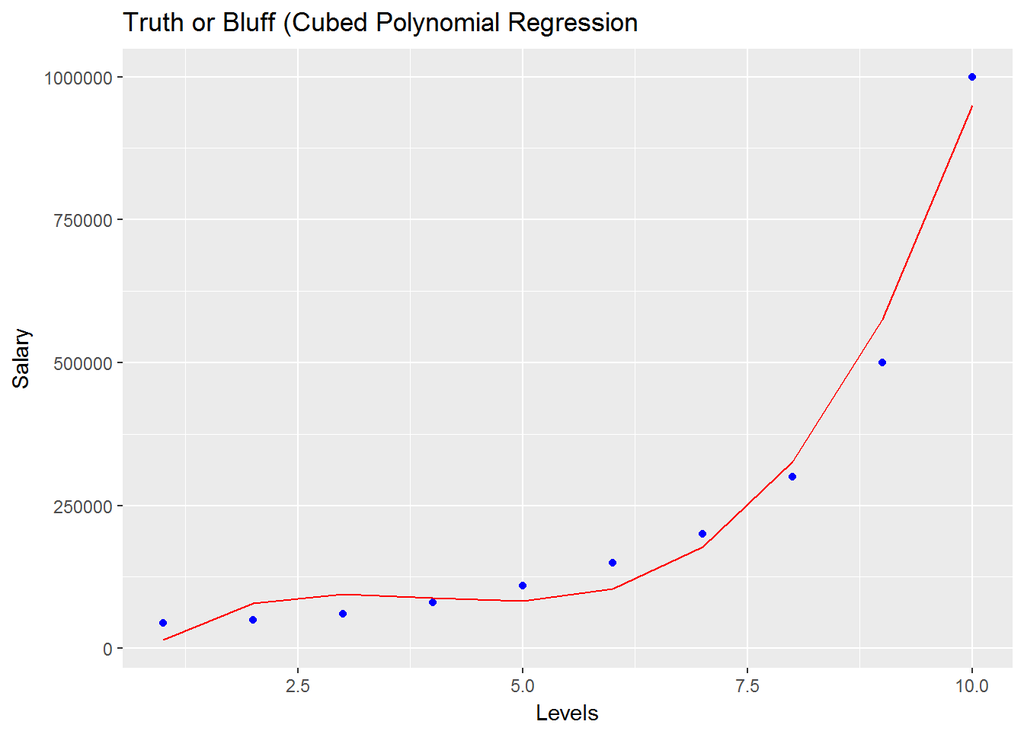

```r
y.pred_3 <- predict(poly_reg_3, new_salaries)

(cubed_plot <- ggplot(new_salaries) +
  geom_point(aes(Level, Salary), colour = 'blue') + # plot points
  geom_line(aes(Level, y.pred_3), colour = 'red') + # plot regression line
  xlab('Levels') +
  ggtitle('Truth or Bluff (Cubed Polynomial Regression'))
```

Well, this looks like it might be overfit. Let’s compare it to the simple linear regression.

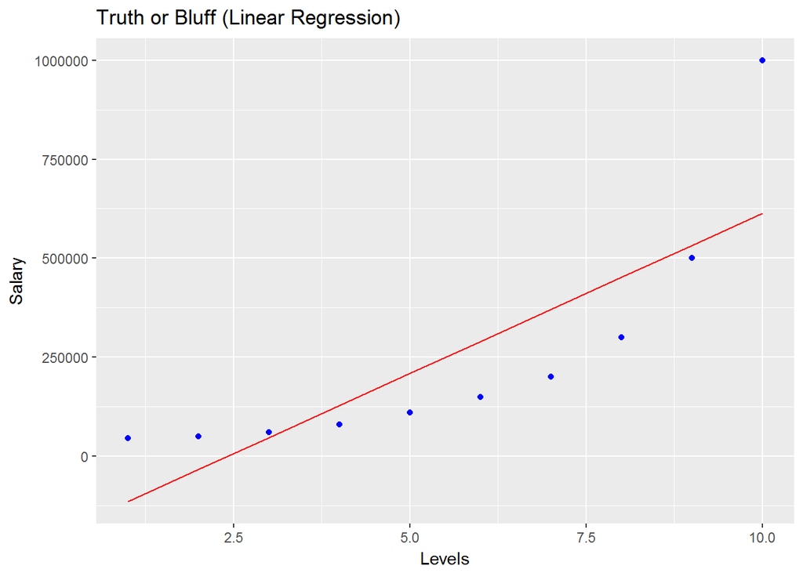

```r
y.pred_lr <- predict(lin_reg, new_salaries)

ggplot(new_salaries) +
  geom_point(aes(Level, Salary), colour = 'blue') + # plot points
  geom_line(aes(Level, y.pred_lr), colour = 'red') + # plot regression line
  xlab('Levels') +
  ggtitle('Truth or Bluff (Linear Regression)')
```

According to this model, if we’re hiring a new CEO, they would be furious when we’d suggest a salary of $600k, when in actuality, it should be ~$1M.

In our situation, a level 6.5 position employee is asking for $160k, and we’d predicted his salary was over $250k, which would be good for us if it were true, as we’re saving money by paying him much less than we predicted he *was* earning.

Looking at the 2nd-order polynomial regression,

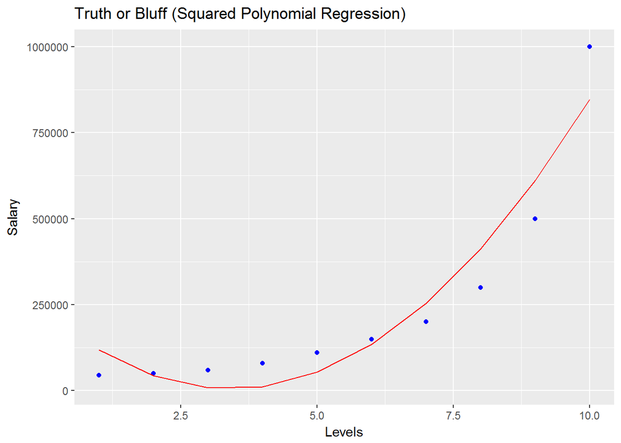

```r
squared_plot
```

Checking the 3rd-order polynomial linear regression:

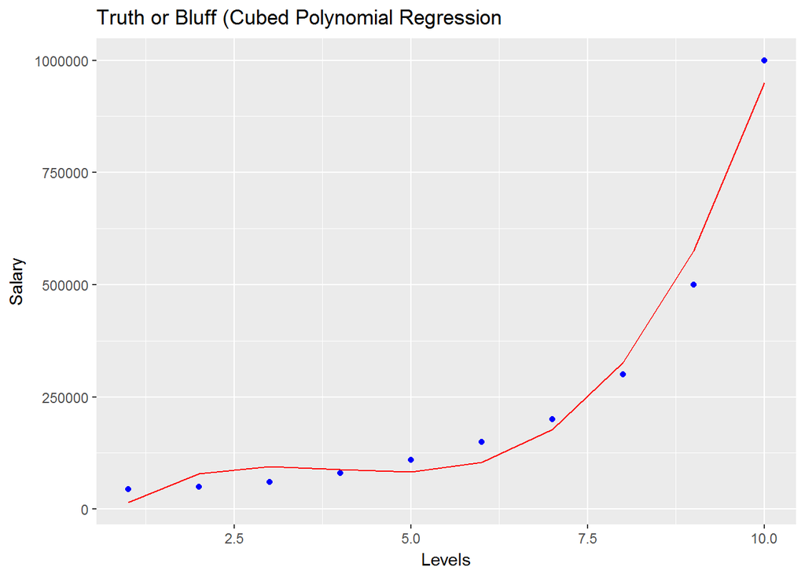

```r
cubed_plot
```

Now we’re pretty close to the actual values with our predictions, and we’d still offer < $160k for level 6.5 position.

As we add more and more degrees, we have higher **order of contact** between the real value **f(x)** for salaries and our expansion/prediction predicted values **g(x)**

For kicks, look at the 4th-order polynomial.

```r
new_salaries$level_quart <- new_salaries$Level^4
poly_reg_4 <- lm(Salary ~., new_salaries)
summary(poly_reg_4)
```

```
##
## Call:
## lm(formula = Salary ~ ., data = new_salaries)
##
## Residuals:
##      1      2      3      4      5      6      7      8      9     10
##  -8357  18240   1358 -14633 -11725   6725  15997  10006 -28695  11084
##
## Coefficients:
##              Estimate Std. Error t value Pr(>|t|)
## (Intercept)  184166.7    67768.0   2.718  0.04189 *
## Level       -211002.3    76382.2  -2.762  0.03972 *
## level_sq      94765.4    26454.2   3.582  0.01584 *
## level_cub    -15463.3     3535.0  -4.374  0.00719 **
## level_quart     890.2      159.8   5.570  0.00257 **
## ---
## Signif. codes:  0 '***' 0.001 '**' 0.01 '*' 0.05 '.' 0.1 ' ' 1
##
## Residual standard error: 20510 on 5 degrees of freedom
## Multiple R-squared:  0.9974, Adjusted R-squared:  0.9953
## F-statistic: 478.1 on 4 and 5 DF,  p-value: 1.213e-06
```

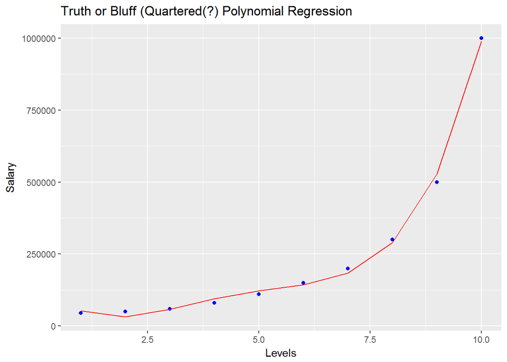

```r
y.pred_4 <- predict(poly_reg_4, new_salaries)

(quartered_plot <- ggplot(new_salaries) +
  geom_point(aes(Level, Salary), colour = 'blue') + # plot points
  geom_line(aes(Level, y.pred_4), colour = 'red') + # plot regression line
  xlab('Levels') +
  ggtitle('Truth or Bluff (Quartered(?) Polynomial Regression'))
```

This will be our final model for this lesson.

## TEST PREDICTIONS WITH DIFFERENT MODELS

Now, we will predict a *single, new* result with Simple Linear Regression, of a level = 6.5

```r
single_prediction_lin_reg <- data.frame(Level = 6.5)
(final_y_predict_lr <- predict(lin_reg, single_prediction_lin_reg))
```

```
##        1
## 330378.8
```

This prediction says the interviewee’s salaray was $330,378.8, so right now he’s asking for less, which is good for us, but not accurate.

Check with the polynomial linear regressions.

```r
## predict a single new result with Polynomial Linear Regression
single_prediction_poly_reg <- data.frame(Level = 6.5, level_sq = 6.5^2, level_cub = 6.5^3, level_quart = 6.5^4)
(final_y_predict_poly <- predict(poly_reg_4, single_prediction_poly_reg))
```

```
##        1
## 158862.5
```

So our “final” prediction for his previous salary was $158,862.5, so right now he’s asking for a bit more, which is good for him, and it’s not that much more, so it’s not bad for us.

Now, we can go forward with our negotiations on a good note, as this employee was honest.